# Quantifying effort and distribution of PSPAP gears

19 May, 2017

## Objectives

In carrying out the goals of the PSPAP, it is important to understand the use of gears over space and time. Catch effort by gear is linked both to data collection costs (including man-hours for gear deployment), as well as power to detect changes in population size. Both costs and detection power are important for determining optimal data collection strategies for accurate population estimation under budget constraints. To study effort by gear type and frequency of gear use, we address the following objectives:

1. Characterize temporal use of gear for PSPAP duration.
2. Quantify effort and associated dispersion for each PSPAP standard gear.

## Methods

For all analyses, the data for the lower and upper basins were considered separately. Using the data entries for which effort could be calculated (see the following paragraph), the number of deployments for each gear was calculated to measure frequency of use. Deployments of each gear were considered over time (by year), as well as over space and time (by bend within river segment and year).

The effort, or the time (in minutes) that a gear was set for in a single deployment, was calculated using the start and stop times given in the PSPAP database. Hence, all data without a start or stop time was excluded from this analysis. The relevant data entries from the PSPAP database were merged with the gear data. A stop date column was added to take into account gears that are set over night, and all data entries using times in AM/PM format were converted to 24 hour clock times. Effort was calculated as the difference between the stop time and the set time in minutes, and negative effort values were removed from the analysis. All calculations were done using the statistical computing environment R. Any differences in the set date and stop date were taken into account by using the “strptime” function in R to link the start and stop times to their corresponding set and stop dates, respectively.

## Results

As expected, results varied by basin. In the lower basin trotlines TLC4 were deployed the least (24 times) and mini-fike nets were deployed the most (7,411 times) out of all common gear types across the PSPAP duration (Table 4). In the upper basin, trotlines TLO1 were the least deployed common gear type (20 times) and trammel nets were the most deployed common gear type (10,915 times) throughout the 14 years reported. Gear deployment also varied by year and bend.

### Gear Use Over Time by Basin

In the lower basin, mini-fyke nets (MF), trammel nets (TN), and 3 types of gill nets (GN14, GN18, GN81) were each deployed during every year of the PSPAP (see Table 1). Additionally, Table 1 reveals, that a fourth gill net (GN41), as well as otter trawls (OT16) and 2 trotline configurations (TLC1, TLC2) were used regularly in the lower basin over the PSPAP duration. While none of the gears were deployed in the upper basin every year of the PSPAP, mini-fyke nets (MF), otter trawls (OT16), trammel nets (TN), 2 configurations of gill nets (GN14, GN41), and one configuration of trotlines (TLC1) were used consistently.

Figure 1 nicely illustrates the data in Table 1. Each dot in Figure 1 is associated with a gear and year, and represents that at least one deployment was made by the indicated gear during the given year. All of the deployment dots are connected by lines to illustrate the use of the gear over time. Hence, the gears that were used consistently, are those that have dots and lines that expand across the majority of the years. In the upper basin, Figure 1 shows that the gears used most consistently were deployed all but 1 or 2 years of the study with these years most likely being near the beginning of the study.

### Gear Use Over Time by Bend

Gear deployments over time are also important at a smaller spatial scale: by bend within river segment. Table 2 gives the number of deployments of each gear type within a particular bend during each year of the PSPAP. This information is summarized in Table 3.

No bend was sampled by standard gears during every year of the PSPAP. Two lower basin bends (segment 13 bend 45 and segment 28 bend 5) and three upper basin bends (segment 15 bend 21 and segment 21 bends 2 and 3) were sampled the least at only one deployment of a standard gear in the 14 years of the PSPAP. These lower basin bends were sampled by a trotline (TLS2 & TLC2, respectively) while the upper basin bends were sampled by a trammel net. Overall, the bend with the most total deployments of standard gears over the course of the PSPAP was bend 17 within the upper basin river segment 4 at a total of 718 deployments. In the lower basin, river segment 7 bend 4 had the highest standard gear usage with 368 deployments.

As seen in Table 3, several standard gears were deployed only once in a given bend over the entire duration of the PSPAP. On the opposite side of the spectrum, in 2005 there were 204 trammel nets deployed within upper basin segment 4 bend 14—the most deployments of a particular standard gear in a river bend in any year. Across years, the most deployments of a single gear type by bend was 502 trammel net deployments, which occurred in upper basin bend 17 within river segment 4. In the lower basin, the most deployments of a single gear type within a year was 32, which occurred in two different bends during different years: bend 17 in segment 7 (32 mini-fyke nets in 2010) and bend 1 in segment 9 (32 TLS1 trotlines in 2007). Across years, segment 7 bend 4 had the most gear deployments (127 trotlines, configuration TLC1).

### Effort Analysis

In general, gamma distributions provided a good fit to the effort data. The two scenarios that were not fit as well as others, were those where the effort data seemed to have multiple modes (LB: TLS1; UB: OT16, TLC1) and those where one effort level occurred often and several other effort levels occurred rarely, resulting in a probability density function with a large spike (LB: TN; UB:GN81, TLC2).

## Figures

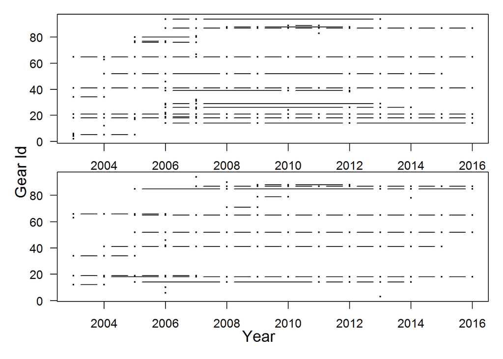

Figure 1. Illustration of gears used since 2003 for Pallid Sturgeon Population assessment in the Missouri River. Top panel is for Lower basin (RPMA 4) and bottom panel is for Upper basin (RPMA 2).

## Tables

Table 1. Summary of frequency of use for each gear type by year. An asterisk (*) following a gear name indicates that the data from this gear was used in the effort analysis (summarized in Table 4).

| Basin | PSPAP gear code | Gear id | 2003 | 2004 | 2005 | 2006 | 2007 | 2008 | 2009 | 2010 | 2011 | 2012 | 2013 | 2014 | 2015 | 2016 |
| --- | --- | --- | --- | --- | --- | --- | --- | --- | --- | --- | --- | --- | --- | --- | --- | --- |
| LB | BSHU | 2 | 2 | 0 | 0 | 0 | 0 | 0 | 0 | 0 | 0 | 0 | 0 | 0 | 0 | 0 |
| LB | BSQU | 4 | 4 | 0 | 0 | 0 | 0 | 0 | 0 | 0 | 0 | 0 | 0 | 0 | 0 | 0 |
| LB | BSRD | 5 | 1 | 15 | 3 | 0 | 0 | 0 | 0 | 0 | 0 | 0 | 0 | 0 | 0 | 0 |
| LB | BSRU | 6 | 57 | 0 | 0 | 0 | 0 | 0 | 0 | 0 | 0 | 0 | 0 | 0 | 0 | 0 |
| LB | BTF | 12 | 0 | 106 | 0 | 0 | 0 | 0 | 0 | 0 | 0 | 0 | 0 | 0 | 0 | 0 |
| LB | FISH | 14 | 0 | 0 | 0 | 6 | 1 | 0 | 2 | 0 | 0 | 3 | 0 | 0 | 0 | 2 |
| LB | FN18 | 38 | 0 | 0 | 0 | 0 | 0 | 0 | 0 | 0 | 0 | 10 | 0 | 0 | 0 | 0 |
| LB | FN36 | 39 | 0 | 0 | 0 | 6 | 0 | 0 | 0 | 24 | 0 | 8 | 0 | 0 | 0 | 0 |
| LB | G4IN | 17 | 0 | 0 | 1 | 0 | 0 | 0 | 0 | 0 | 0 | 0 | 0 | 0 | 0 | 0 |
| LB | GN14* | 18 | 6 | 36 | 78 | 158 | 133 | 149 | 131 | 21 | 109 | 111 | 107 | 124 | 240 | 120 |
| LB | GN14G | 19 | 0 | 0 | 0 | 13 | 28 | 0 | 0 | 0 | 0 | 0 | 0 | 0 | 0 | 0 |
| LB | GN18* | 21 | 216 | 178 | 261 | 556 | 439 | 345 | 385 | 388 | 397 | 358 | 353 | 324 | 383 | 115 |
| LB | GN18G | 22 | 0 | 0 | 0 | 3 | 0 | 0 | 0 | 0 | 0 | 0 | 0 | 0 | 0 | 0 |
| LB | GN3 | 25 | 0 | 0 | 0 | 0 | 2 | 0 | 0 | 0 | 0 | 0 | 0 | 0 | 0 | 0 |
| LB | GN41* | 18 | 10 | 23 | 72 | 175 | 107 | 94 | 110 | 49 | 101 | 129 | 133 | 115 | 0 | 0 |
| LB | GN41G | 19 | 0 | 0 | 0 | 6 | 21 | 0 | 0 | 0 | 0 | 0 | 0 | 0 | 0 | 0 |
| LB | GN81* | 21 | 84 | 168 | 225 | 431 | 386 | 352 | 335 | 300 | 400 | 331 | 327 | 350 | 291 | 114 |
| LB | GN81G | 22 | 0 | 0 | 0 | 1 | 0 | 0 | 0 | 0 | 0 | 0 | 0 | 0 | 0 | 0 |
| LB | GNH3 | 26 | 0 | 0 | 0 | 14 | 6 | 0 | 0 | 0 | 0 | 5 | 13 | 2 | 0 | 0 |
| LB | GNH3T | 28 | 0 | 0 | 0 | 1 | 0 | 0 | 0 | 0 | 0 | 0 | 0 | 0 | 0 | 0 |
| LB | GNM18 | 24 | 0 | 0 | 0 | 0 | 0 | 0 | 0 | 1 | 0 | 0 | 0 | 0 | 0 | 0 |
| LB | GNM25 | 31 | 0 | 0 | 0 | 0 | 16 | 0 | 0 | 0 | 0 | 0 | 0 | 0 | 0 | 0 |
| LB | GNM31 | 32 | 0 | 0 | 0 | 0 | 4 | 0 | 0 | 0 | 0 | 0 | 0 | 0 | 0 | 0 |
| LB | GNMN3 | 29 | 0 | 0 | 0 | 4 | 2 | 0 | 0 | 0 | 0 | 0 | 5 | 0 | 0 | 0 |
| LB | HN | 34 | 354 | 370 | 0 | 0 | 0 | 0 | 0 | 0 | 0 | 0 | 0 | 0 | 0 | 0 |
| LB | MF* | 41 | 163 | 194 | 635 | 654 | 686 | 703 | 714 | 541 | 211 | 697 | 714 | 706 | 713 | 80 |
| LB | OT01 | 46 | 0 | 0 | 0 | 1 | 0 | 0 | 0 | 0 | 0 | 0 | 0 | 0 | 0 | 0 |
| LB | OT16* | 52 | 0 | 148 | 22 | 38 | 0 | 6 | 1 | 0 | 0 | 71 | 293 | 15 | 12 | 0 |
| LB | POT02 | 94 | 0 | 0 | 0 | 16 | 8 | 0 | 0 | 0 | 0 | 0 | 25 | 0 | 0 | 0 |
| LB | SL | 63 | 0 | 3 | 0 | 0 | 0 | 0 | 0 | 0 | 0 | 0 | 0 | 0 | 0 | 0 |

[output cut: 53 more lines]

Table 2. Frequency of use (number of deployments) for each standard gear type by bend (within river segment) and year. An asterisk (*) following a gear name indicates that the data from this gear was used in the effort analysis (summarized in Table 4).

| Basin | Segment | Bend | PSPAP gear code | Gear id | 2003 | 2004 | 2005 | 2006 | 2007 | 2008 | 2009 | 2010 | 2011 | 2012 | 2013 | 2014 | 2015 | 2016 |
| --- | --- | --- | --- | --- | --- | --- | --- | --- | --- | --- | --- | --- | --- | --- | --- | --- | --- | --- |
| LB | 7 | 1 | TLC1* | 87 | 0 | 0 | 0 | 0 | 0 | 5 | 8 | 16 | 16 | 8 | 0 | 8 | 0 | 0 |
| LB | 7 | 1 | TLC2* | 87 | 0 | 0 | 0 | 0 | 0 | 5 | 0 | 0 | 0 | 0 | 0 | 0 | 0 | 0 |
| LB | 7 | 2 | GN14* | 18 | 0 | 0 | 4 | 5 | 6 | 7 | 5 | 2 | 5 | 3 | 5 | 0 | 0 | 0 |
| LB | 7 | 2 | GN41* | 18 | 0 | 0 | 6 | 5 | 4 | 3 | 5 | 8 | 5 | 7 | 5 | 0 | 0 | 0 |
| LB | 7 | 2 | MF* | 41 | 0 | 0 | 0 | 8 | 0 | 8 | 0 | 8 | 0 | 0 | 8 | 0 | 0 | 0 |
| LB | 7 | 2 | OT16* | 52 | 0 | 0 | 0 | 8 | 0 | 0 | 0 | 0 | 0 | 0 | 0 | 0 | 0 | 0 |
| LB | 7 | 2 | TLC1* | 87 | 0 | 0 | 0 | 0 | 0 | 18 | 8 | 24 | 16 | 8 | 0 | 8 | 8 | 0 |
| LB | 7 | 2 | TLC2* | 87 | 0 | 0 | 0 | 0 | 0 | 15 | 0 | 0 | 0 | 0 | 0 | 0 | 0 | 0 |
| LB | 7 | 3 | GN14* | 18 | 0 | 6 | 3 | 17 | 6 | 6 | 7 | 0 | 7 | 3 | 7 | 11 | 10 | 10 |
| LB | 7 | 3 | GN41* | 18 | 0 | 1 | 7 | 16 | 4 | 4 | 3 | 0 | 3 | 7 | 13 | 9 | 0 | 0 |
| LB | 7 | 3 | MF* | 41 | 0 | 0 | 10 | 10 | 8 | 0 | 8 | 0 | 0 | 0 | 8 | 8 | 0 | 0 |
| LB | 7 | 3 | OT16* | 52 | 0 | 0 | 0 | 4 | 0 | 0 | 0 | 0 | 0 | 0 | 0 | 0 | 0 | 0 |
| LB | 7 | 3 | TLC1* | 87 | 0 | 0 | 0 | 0 | 0 | 10 | 16 | 24 | 16 | 8 | 8 | 8 | 16 | 0 |
| LB | 7 | 3 | TLC2* | 87 | 0 | 0 | 0 | 0 | 0 | 12 | 0 | 0 | 0 | 0 | 0 | 0 | 0 | 0 |
| LB | 7 | 3 | TN* | 65 | 0 | 0 | 10 | 0 | 0 | 0 | 0 | 0 | 0 | 0 | 0 | 0 | 0 | 0 |
| LB | 7 | 4 | GN14* | 18 | 0 | 0 | 0 | 8 | 14 | 5 | 6 | 3 | 8 | 2 | 3 | 13 | 20 | 10 |
| LB | 7 | 4 | GN41* | 18 | 0 | 0 | 0 | 7 | 6 | 5 | 5 | 7 | 2 | 8 | 7 | 7 | 0 | 0 |
| LB | 7 | 4 | MF* | 41 | 0 | 0 | 10 | 0 | 8 | 8 | 0 | 8 | 0 | 8 | 0 | 8 | 8 | 8 |
| LB | 7 | 4 | OT16* | 52 | 0 | 0 | 0 | 0 | 0 | 0 | 0 | 0 | 0 | 0 | 0 | 1 | 0 | 0 |
| LB | 7 | 4 | TLC1* | 87 | 0 | 0 | 0 | 0 | 0 | 15 | 8 | 24 | 24 | 16 | 8 | 16 | 16 | 0 |
| LB | 7 | 4 | TLC2* | 87 | 0 | 0 | 0 | 0 | 0 | 17 | 0 | 0 | 0 | 0 | 0 | 0 | 0 | 0 |
| LB | 7 | 4 | TN* | 65 | 0 | 0 | 11 | 0 | 0 | 0 | 0 | 0 | 0 | 0 | 0 | 0 | 0 | 0 |
| LB | 7 | 5 | GN14* | 18 | 0 | 0 | 0 | 0 | 6 | 6 | 6 | 3 | 6 | 3 | 0 | 5 | 10 | 10 |
| LB | 7 | 5 | GN41* | 18 | 0 | 0 | 0 | 0 | 4 | 4 | 4 | 7 | 4 | 7 | 0 | 5 | 0 | 0 |
| LB | 7 | 5 | MF* | 41 | 0 | 0 | 0 | 0 | 0 | 8 | 0 | 8 | 0 | 8 | 0 | 0 | 0 | 8 |
| LB | 7 | 5 | TLC1* | 87 | 0 | 0 | 0 | 0 | 0 | 5 | 8 | 24 | 16 | 16 | 8 | 0 | 0 | 8 |
| LB | 7 | 5 | TLC2* | 87 | 0 | 0 | 0 | 0 | 0 | 5 | 0 | 0 | 0 | 0 | 0 | 0 | 0 | 0 |
| LB | 7 | 6 | GN14* | 18 | 0 | 3 | 6 | 3 | 0 | 4 | 4 | 0 | 7 | 0 | 6 | 12 | 10 | 0 |
| LB | 7 | 6 | GN41* | 18 | 0 | 4 | 8 | 5 | 0 | 6 | 6 | 0 | 3 | 0 | 4 | 8 | 0 | 0 |
| LB | 7 | 6 | MF* | 41 | 0 | 0 | 7 | 9 | 0 | 0 | 8 | 0 | 0 | 0 | 0 | 8 | 8 | 0 |

[output cut: 2411 more lines]

Table 3. Summary of the number of deployments for each standard gear type by bend (within river segment) per year. An asterisk (*) following a gear name indicates that the data from this gear was used in the effort analysis (summarized in Table 4).

| Basin | Segment | Bend | PSPAP gear code | Gear id | Minimum | Maximum | Mean | Median | Total Deployments |
| --- | --- | --- | --- | --- | --- | --- | --- | --- | --- |
| LB | 7 | 1 | TLC1* | 87 | 0 | 16 | 4.4 | 0.0 | 61 |
| LB | 7 | 1 | TLC2* | 87 | 0 | 5 | 0.4 | 0.0 | 5 |
| LB | 7 | 2 | GN14* | 18 | 0 | 7 | 3.0 | 3.5 | 42 |
| LB | 7 | 2 | GN41* | 18 | 0 | 8 | 3.4 | 4.5 | 48 |
| LB | 7 | 2 | MF* | 41 | 0 | 8 | 2.3 | 0.0 | 32 |
| LB | 7 | 2 | OT16* | 52 | 0 | 8 | 0.6 | 0.0 | 8 |
| LB | 7 | 2 | TLC1* | 87 | 0 | 24 | 6.4 | 4.0 | 90 |
| LB | 7 | 2 | TLC2* | 87 | 0 | 15 | 1.1 | 0.0 | 15 |
| LB | 7 | 3 | GN14* | 18 | 0 | 17 | 6.6 | 6.5 | 93 |
| LB | 7 | 3 | GN41* | 18 | 0 | 16 | 4.8 | 3.5 | 67 |
| LB | 7 | 3 | MF* | 41 | 0 | 10 | 3.7 | 0.0 | 52 |
| LB | 7 | 3 | OT16* | 52 | 0 | 4 | 0.3 | 0.0 | 4 |
| LB | 7 | 3 | TLC1* | 87 | 0 | 24 | 7.6 | 8.0 | 106 |
| LB | 7 | 3 | TLC2* | 87 | 0 | 12 | 0.9 | 0.0 | 12 |
| LB | 7 | 3 | TN* | 65 | 0 | 10 | 0.7 | 0.0 | 10 |
| LB | 7 | 4 | GN14* | 18 | 0 | 20 | 6.6 | 5.5 | 92 |
| LB | 7 | 4 | GN41* | 18 | 0 | 8 | 3.9 | 5.0 | 54 |
| LB | 7 | 4 | MF* | 41 | 0 | 10 | 4.7 | 8.0 | 66 |
| LB | 7 | 4 | OT16* | 52 | 0 | 1 | 0.1 | 0.0 | 1 |
| LB | 7 | 4 | TLC1* | 87 | 0 | 24 | 9.1 | 8.0 | 127 |
| LB | 7 | 4 | TLC2* | 87 | 0 | 17 | 1.2 | 0.0 | 17 |
| LB | 7 | 4 | TN* | 65 | 0 | 11 | 0.8 | 0.0 | 11 |
| LB | 7 | 5 | GN14* | 18 | 0 | 10 | 3.9 | 4.0 | 55 |
| LB | 7 | 5 | GN41* | 18 | 0 | 7 | 2.5 | 2.0 | 35 |
| LB | 7 | 5 | MF* | 41 | 0 | 8 | 2.3 | 0.0 | 32 |
| LB | 7 | 5 | TLC1* | 87 | 0 | 24 | 6.1 | 2.5 | 85 |
| LB | 7 | 5 | TLC2* | 87 | 0 | 5 | 0.4 | 0.0 | 5 |
| LB | 7 | 6 | GN14* | 18 | 0 | 12 | 3.9 | 3.5 | 55 |
| LB | 7 | 6 | GN41* | 18 | 0 | 8 | 3.1 | 3.5 | 44 |
| LB | 7 | 6 | MF* | 41 | 0 | 9 | 2.9 | 0.0 | 40 |

[output cut: 2411 more lines]

Table 4. Summary of effort data (minutes of use per catch trial) for each common gear type.

| Basin | PSPAP gear code | Gear id | No. of Obs. | Mean Effort | Standard Deviation | Minimum | Maximum | Median | Gamma_Shape | Gamma_Rate |
| --- | --- | --- | --- | --- | --- | --- | --- | --- | --- | --- |
| LB | GN14 | 18 | 1523 | 1326 | 89 | 1002 | 1633 | 1333 | 224.493086 | 0.1692404 |
| LB | GN18 | 21 | 4698 | 1221 | 123 | 750 | 1695 | 1221 | 98.540664 | 0.0807099 |
| LB | GN41 | 18 | 1118 | 1327 | 91 | 969 | 1563 | 1340 | 210.667976 | 0.1587651 |
| LB | GN81 | 21 | 4094 | 1219 | 117 | 750 | 1678 | 1222 | 109.460899 | 0.0897863 |
| LB | MF | 41 | 7411 | 1278 | 126 | 729 | 2106 | 1288 | 103.412037 | 0.0808979 |
| LB | OT16 | 52 | 606 | 3 | 7 | 1 | 178 | 2 | 1.986635 | 0.7149057 |
| LB | TLC1 | 87 | 2164 | 1336 | 60 | 1067 | 1542 | 1341 | 500.663839 | 0.3746263 |
| LB | TLC2 | 87 | 5219 | 1206 | 109 | 859 | 1591 | 1210 | 122.773069 | 0.1017996 |
| LB | TLC4 | 87 | 24 | 1273 | 119 | 956 | 1466 | 1262 | 114.454203 | 0.0898943 |
| LB | TLS1 | 87 | 32 | 1067 | 21 | 1015 | 1101 | 1063 | 2598.001770 | 2.4338678 |
| LB | TLS2 | 87 | 381 | 1147 | 103 | 838 | 1419 | 1145 | 123.165495 | 0.1073556 |
| LB | TN | 65 | 1072 | 4 | 3 | 1 | 69 | 3 | 2.568699 | 0.6765714 |
| UB | GN14 | 18 | 700 | 1130 | 183 | 310 | 1751 | 1151 | 29.735758 | 0.0263068 |
| UB | GN41 | 18 | 716 | 1134 | 183 | 295 | 1762 | 1138 | 30.634266 | 0.0270084 |
| UB | MF | 41 | 4281 | 1182 | 142 | 698 | 1708 | 1180 | 69.168422 | 0.0584990 |
| UB | OT16 | 52 | 9081 | 4 | 7 | 1 | 511 | 4 | 6.787978 | 1.6706862 |
| UB | TLC1 | 87 | 3616 | 1120 | 139 | 755 | 1615 | 1119 | 65.327401 | 0.0583306 |
| UB | TLC2 | 87 | 80 | 1025 | 150 | 694 | 1416 | 994 | 49.933263 | 0.0486958 |
| UB | TLO1 | 87 | 20 | 999 | 85 | 824 | 1100 | 1029 | 136.674723 | 0.1367773 |
| UB | TN | 65 | 10915 | 7 | 7 | 1 | 610 | 6 | 5.128287 | 0.7734619 |